# si544-day7-multiple-regression

Matthew Garvin (mgarvin)

10/15/2020

As usual, load all the libraries that we’ll need:

```r
library(tidyverse)
library(moderndive)
library(skimr)
```

Let’s load the Szeged weather data:

```r
weather <- read_csv("https://github.com/umsi-data-science/data/raw/main/weatherHistory.csv")
```

## Learning Check 544.8.1:

Create a dataframe called “weather_day7” based on a random sample of 500 rows from weather that consists of only the following columns: temp (renamed from “Temperature (C)” ), apparent_temp (renamed from “Apparent Temperature ( C)”, humidity (from Humidity), and wind_speed (from “Wind Speed (km/h)”

```r
# INSERT YOUR R CODE HERE
set.seed(42)
weather_day7 <- weather %>%
  select(temp = `Temperature (C)`, apparent_temp = `Apparent Temperature (C)`, humidity = Humidity, wind_speed = `Wind Speed (km/h)`) %>%
  sample_n(500)
```

Let’s take a look at the relationship between apparent_temp and temp, as well as apparent_temp and humidity:

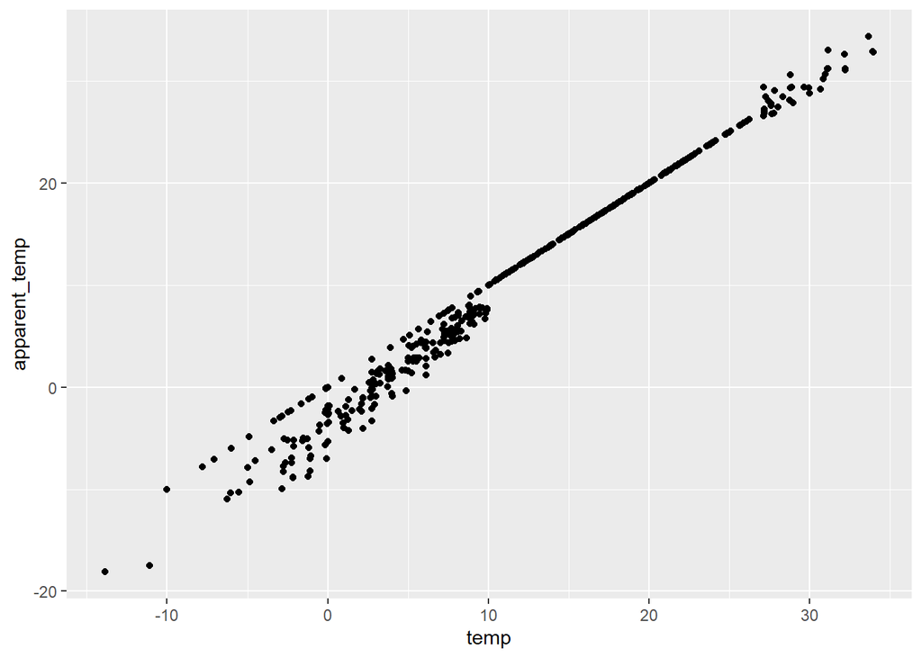

```r
ggplot(weather_day7, mapping=aes(x=temp, y=apparent_temp)) + geom_point()
```

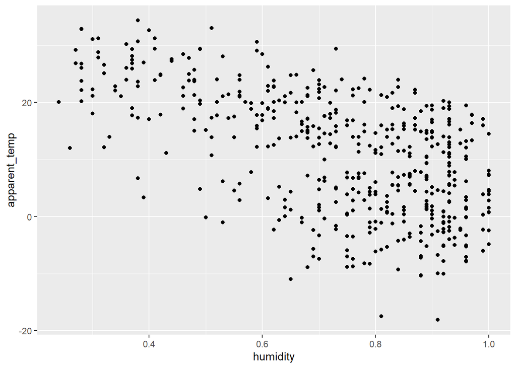

```r
ggplot(weather_day7, mapping=aes(x=humidity, y=apparent_temp)) + geom_point()
```

## Learning Check 544.8.2:

Create a regression that models “Apparent Temperature” in terms of “Temperature”. How good is your model?

```r
# INSERT YOUR R CODE HERE
r_model <- lm(apparent_temp ~ temp, data = weather_day7)
# Get regression table:
get_regression_table(r_model)
```

```
## # A tibble: 2 x 7
##   term      estimate std_error statistic p_value lower_ci upper_ci
##   <chr>        <dbl>     <dbl>     <dbl>   <dbl>    <dbl>    <dbl>
## 1 intercept    -2.64     0.094     -28.0       0    -2.83    -2.46
## 2 temp          1.12     0.006     183.        0     1.11     1.14
```

```r
get_regression_summaries(r_model)
```

```
## # A tibble: 1 x 8
##   r_squared adj_r_squared   mse  rmse sigma statistic p_value    df
##       <dbl>         <dbl> <dbl> <dbl> <dbl>     <dbl>   <dbl> <dbl>
## 1     0.985         0.985  1.64  1.28  1.28    33309.       0     2
```

Let’s look at a model of apparent_temperature that uses temp and humidity as explanatory variables:

```r
weather_model <- lm(apparent_temp ~ temp*humidity
                   ,data=weather_day7)
get_regression_table(weather_model)
```

```
## # A tibble: 4 x 7
##   term          estimate std_error statistic p_value lower_ci upper_ci
##   <chr>            <dbl>     <dbl>     <dbl>   <dbl>    <dbl>    <dbl>
## 1 intercept       -4.46      0.548     -8.15   0       -5.54     -3.39
## 2 temp             1.12      0.025     45.4    0        1.08      1.17
## 3 humidity         1.96      0.651      3.01   0.003    0.682     3.24
## 4 temp:humidity    0.047     0.032      1.48   0.141   -0.016     0.11
```

```r
get_regression_summaries(weather_model)
```

```
## # A tibble: 1 x 8
##   r_squared adj_r_squared   mse  rmse sigma statistic p_value    df
##       <dbl>         <dbl> <dbl> <dbl> <dbl>     <dbl>   <dbl> <dbl>
## 1     0.987         0.987  1.46  1.21  1.21    12458.       0     4
```

## Learning Check 544.8.3:

Create a linear regression model for apparent_temp that includes temperature, humidity, and wind speed as explanatory variables. Calculate the apparent temperature when the temperature is 20 degrees Celsius, the humidity 65%, and the wind speed 20 km/h.

```r
# INSERT YOUR R CODE HERE
weather_model2 <- lm(apparent_temp ~ temp*humidity*wind_speed
                   ,data=weather_day7)
get_regression_table(weather_model2)
```

```
## # A tibble: 8 x 7
##   term                    estimate std_error statistic p_value lower_ci upper_ci
##   <chr>                      <dbl>     <dbl>     <dbl>   <dbl>    <dbl>    <dbl>
## 1 intercept                 -1.50      0.563    -2.67    0.008   -2.61    -0.399
## 2 temp                       1.03      0.025    41.0     0        0.98     1.08
## 3 humidity                   1.58      0.65      2.43    0.015    0.304    2.86
## 4 wind_speed                 0.049     0.035     1.4     0.162   -0.02     0.119
## 5 temp:humidity             -0.02      0.031    -0.628   0.53    -0.081    0.042
## 6 temp:wind_speed           -0.005     0.002    -2.72    0.007   -0.008   -0.001
## 7 humidity:wind_speed       -0.359     0.044    -8.25    0       -0.444   -0.273
## 8 temp:humidity:wind_spe~    0.024     0.002     9.42    0        0.019    0.028
```

```r
get_regression_summaries(weather_model2)
```

```
## # A tibble: 1 x 8
##   r_squared adj_r_squared   mse  rmse sigma statistic p_value    df
##       <dbl>         <dbl> <dbl> <dbl> <dbl>     <dbl>   <dbl> <dbl>
## 1     0.996         0.996 0.402 0.634 0.639    19364.       0     8
```

```r
-1.505 + 1.029*20 + 1.580*.65 +20*20*(-.005) + .65*20*(-0.359) + 20*.65*20*0.024
```

```
## [1] 19.675
```